# Final Paper

STOR 320.02 Group 3

April 26, 2022

# INTRODUCTION:

> College basketball—if you’re an American, chances are that you know something about college basketball, whether you like it or not. Being at a college like UNC, it is almost impossible not to care about college basketball. Just this past year, the UNC men’s basketball team went to the NCAA Division 1 National Championship, *and* Governor Roy Cooper deemed North Carolina as “the center of the college basketball universe.” Every year, the NCAA Division I Men’s Basketball Tournament—aka March Madness—comes around, and it’s time to create our brackets. Creating a successful bracket can result in bragging rights and, depending on the wager, a hefty sum of money. Everybody wants to create the best bracket they can, but many people never really know where to begin. Our analysis focuses on making predictions for college basketball teams, so that next year, we (and you too) can win the bracket challenges.

#### Question 1: Which conferences on average have improved the most in 3 metrics?

> Our first question focuses on different conferences in college basketball and on average which of these conferences have improved based off of three metrics: the power rating, the turnover rate, and the winning percentage. This question helps us understand which conference is “best” since there is always an ongoing debate on which conferences should be considered the “power five conferences”. Typically power five is considered as ACC, Big 10, Big12, Pac 12, and SEC. Although the teams within this conference may see higher efficiencies, they may not experience as much growth. However, Determining the conferences that excelled the best in these metrics will help with predictions later on as well as understanding how talent within a conference changes over time.

#### Question 2: Can we predict how far a school will go in the tournament?

> Our second question focuses more on whether or not we could predict how far a school will go in the NCAA. It is a question that many would be interested in since everybody wants their March Madness brackets to be the best and our analysis would help them see what would count as the best predictors in the same. The odds of a perfect bracket being 1 in 9.2 quintillion and upsets are almost luck-based when it comes to predictions. However through data analysis and trends it is possible to predict upsets, final four teams, and other categories improving a bracket. The information in this data set allows our group to answer questions based around improvements and tournament predictions.

# DATA:

The data we used was called the “College Basketball Dataset”, which we briefly touched on in the introduction, was retrieved off Kaggle. It contained data from 2013, 2014, 2015, 2016, 2017, 2018, 2019, 2020, and 2021 Division I college basketball seasons. However, it was originally scraped from the following domain, http://www.barttorvik.com/#. The original data was messy to look at, for reference look at the figure below.

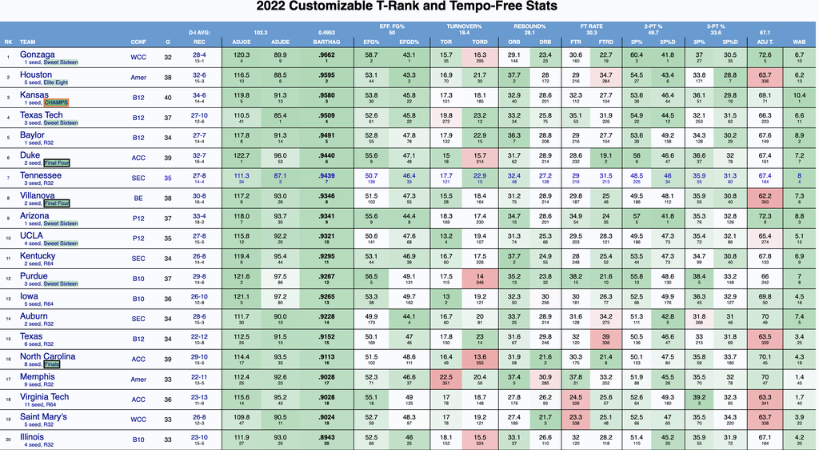

$$Offensive Efficiency = 100 * \frac{Points Scored}{Posessions}$$
$$Defensive Efficiency = 100 * \frac{Points Allowed}{Posessions}$$
$$ADE = \frac{Defensive Efficiency * National Avg D1 Defensive Efficiency}{National Avg D1 Offensive Efficiency}$$

These variables help judge the strength of a team’s offensive and defensive abilities. These are beneficial as it allows teams to be better compared to each other and the national average for these metrics. A key variable that helps us answer our second key question is Postseason. Postseason tells us how far the division I college basketball team went in March Madness or the tournament after the regular season. Originally, the variable was given in confusing outputs that would complicate graphs. The outputs ranged from Champions, E8, 2ND, etc. So in order to easily identify how far a team went in the Postseasons, we changed the following outputs: RD68 = 1 (lost the first game), RD64 = 2, RD32 = 3, S16 = 4, E8 = 5, F4 = 6, 2ND = 7, and Champions = 8 (won the tournament). To better understand Postseason, let us look at the relationship between Postseason and Winning Percenatge.

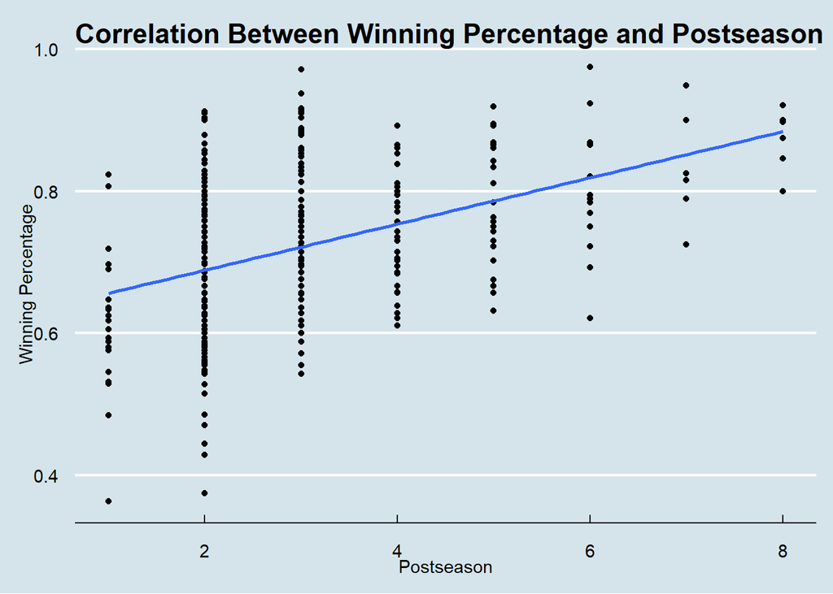

As seen in the figure, the upward sloping line shows the positive correlation between the two variables. In plainer terms, the team that won the tournament in the Postseason would have a higher Winning percentage since they had to win more games to make it to the end of the tournament. Some other key variables are Turnover Rate and Power Rating. Turnover rate is the amount of times a team gives up possession per 100 possession. Power Rating is the chance of the team beating an average division I team.

# RESULTS:

## Question 1:

```r
CBB_Conference= CBB %>% mutate(WinningPercentage = GamesWon / GamesPlayed)

CBB_Conference2= CBB_Conference %>% group_by(Conference, Season)

CBB_Conference3 = CBB_Conference2 %>% summarise(AverageTOR= mean(TurnoverRate),AveragePR= mean(PowerRating),AverageWP=mean(WinningPercentage)) %>% filter(Season %in% c(2013,2019))
```

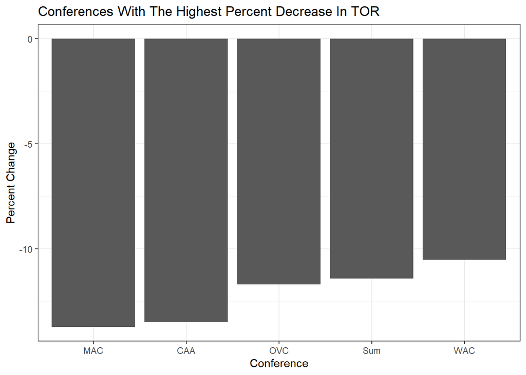

```r
Percentchange= CBB_Conference3 %>% mutate(pct_change_tor = ((AverageTOR/lag(AverageTOR) - 1) * 100)) %>% mutate(pct_change_pr = ((AveragePR/lag(AveragePR) - 1) * 100)) %>% mutate(pct_change_wp = ((AverageWP/lag(AverageWP) - 1) * 100))





PercentChangeTOR= Percentchange[order(Percentchange$pct_change_tor),] %>% select(Conference, pct_change_tor)

Top5ChangeTOR= head(PercentChangeTOR,5)



PercentChangePR= Percentchange[order(-Percentchange$pct_change_pr),] %>% select(Conference, pct_change_pr)

Top5ChangePR= head(PercentChangePR,5)



PercentChangeWP= Percentchange[order(-Percentchange$pct_change_wp),] %>% select(Conference, pct_change_wp)

Top5ChangeWP=head(PercentChangeWP,5)



Top5ChangeTOR$Conference=factor(Top5ChangeTOR$Conference,levels= Top5ChangeTOR$Conference[order(Top5ChangeTOR$pct_change_tor, decreasing=FALSE)])

ggplot(Top5ChangeTOR)+ geom_bar(aes(x= Conference,y=pct_change_tor),stat= "identity") + ggtitle("Conferences With The Highest Percent Decrease In TOR ")+

   xlab("Conference") +ylab("Percent Change")+ theme_bw()
```

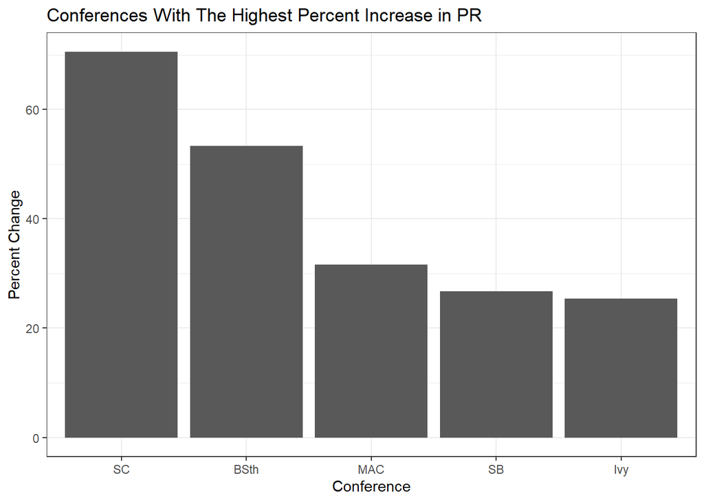

```r
Top5ChangePR$Conference=factor(Top5ChangePR$Conference,levels= Top5ChangePR$Conference[order(Top5ChangePR$pct_change_pr, decreasing=TRUE)])

ggplot(Top5ChangePR)+ geom_bar(aes(x= Conference,y=pct_change_pr),stat= "identity")+ ggtitle("Conferences With The Highest Percent Increase in PR")+

   xlab("Conference") +ylab("Percent Change")+theme_bw()
```

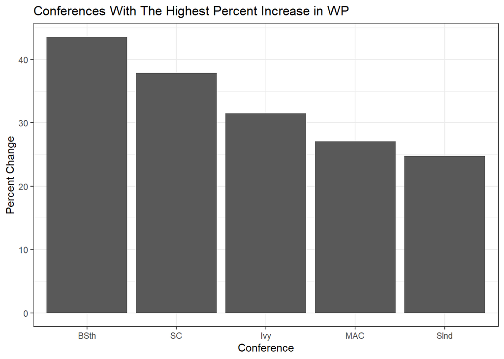

```r
Top5ChangeWP$Conference=factor(Top5ChangeWP$Conference,levels= Top5ChangeWP$Conference[order(Top5ChangeWP$pct_change_wp, decreasing=TRUE)])

ggplot(Top5ChangeWP)+ geom_bar(aes(x= Conference,y=pct_change_wp),stat= "identity")+

  ggtitle("Conferences With The Highest Percent Increase in WP")+

   xlab("Conference") +ylab("Percent Change")+ theme_bw()
```

MAC is a top 5 team in all three categories or variables. This lead us to believe that the conference that has improved the most over the past years is the MAC or Mid-American Conference.

## Question 2:

Our next question attempts to answer as to whether we are able to effectively predict how far a team would be able to go in the Postseason tournament given their stats. We first split the data through random sampling into 80% train sets and 20% test sets. Then we built linear models to predict how far a team goes in the Postseason using a combination of predictors. To determine what were the best predictors, we used Best Subsets Regression, utilizing the regsubsets function within the leaps package. This function helps us find linear models with the least Mallow’s Cp. Mallow’s Cp is a method to compare the full model to smaller models with the best subsets of predictors, with a lower value indicating a better model as it suggests smaller amounts of unexplained error.

Given a smaller dataset that did not include non-numerical variables, along with AOE and ADE as they are included within Power Rating, the best model found was Postseason = EffectiveFieldGoalPercentageAllowed + OffensiveReboundRateAllowed + FreeThrowRate + FreeThrowRateAllowed + TwoPointShootingPercentageAllowed + ThreePointShootingPercentageAllowed + Seed + WinningPercentage. This model gave the lowest Mallow’s Cp of 8.12. The next best model given with 4 predictors is Postseason = OffensiveReboundRateAllowed + FreeThrowRateAllowed + Seed + Winning Percentage with a Mallow’s Cp of 8.41. The third best model is Postseason = OffensiveReboundRateAllowed + FreeThrowRate + FreeThrowRateAllowed + Seed + WinningPercentage with a Mallow’s Cp of 8.64.

With the best three models, we then went to see how accurate they performed. Using the test data, we plotted the linear models with their predicted Postseason value against the actual Postseason value. From the figure below, we have the black line representing a perfect fit with the three linear regression lines.

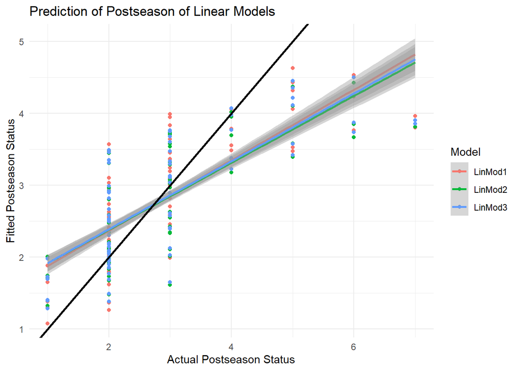

Based on the figure, we see that the three models are very similar due to the proximity of their trend lines. We see there is some success, particularly around the middle where it seems to hit close to center of the distributions of each Postseason status, however we see at later rounds, the models are no longer that accurate predicting. One big reason may be attributed to the lack of data for teams that reached round 6 and beyond, and therefore the models are highly skewed for the earlier rounds. So while these models may have some correlation to predict Postseason status, especially in the earlier rounds, these models may not be the most accurate and may require additional methods to determine better predictors for better accuracy.

# CONCLUSION:

In our analysis we wanted to solve two crucial questions about our data involving basketball. Our first inquiry was about which conference has improved the most over the past years. In doing so, we used three determinant variables that we deemed useful in analyzing the quality of a team. Those variables being turnover rate, winning percentage, and power rating. Although skeptical, we were expecting some if not all power 5 conferences to be some of the most improved teams. In our process in finding the percent increase with the respected variables, we found that no power 5 conference was ranked top 5 in any category. Although unusual at first glance, power 5 teams have very good scores in these three variables already. Thus, their room for improvement is very little compared to non power 5 conferences. Yet, with the findings of smaller conferences having large improvements shows that division I college basketball is becoming more competitive across all conferences and not so dominated by a few conferences. To take this analysis even further, one could make a model to predict the trend of improvements for these conferences in the future. This could help shed light on if these historic power 5 conferences could be taken over by different conferences in the future. With just looking at a short fluctuation from 2013 to 2019 but seeing large improvements in these smaller conferences could mean they will continue to improve in the long run.